# Tugas Pembangkitan Proses AR(2), MA(2), dan ARMA(2,2)

15 September 2026

# Pendahuluan

Tugas ini membangkitkan tiga jenis proses deret waktu sebanyak 300 data, yaitu **MA(2)**, **AR(2)**, dan **ARMA(2,2)**, masing-masing dengan dua cara: secara **manual** (melalui perulangan/*loop* berdasarkan definisi proses) dan menggunakan fungsi bawaan **`arima.sim()`**. Untuk setiap proses dibuat plot *time series*, ACF, PACF, dan EACF untuk mengidentifikasi kestasioneran, scatterplot antar-lag ($Y_t$ dengan $Y_{t-1}$, $Y_{t-2}$, $Y_{t-3}$), serta dihitung autokorelasi dari data bangkitan (empiris) dan secara teoritis.

Seluruh proses dibangkitkan dari *white noise* yang sama agar dapat dibandingkan secara konsisten.

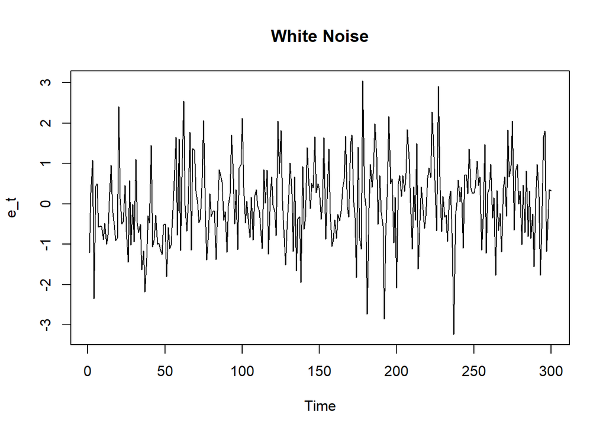

```r
set.seed(1234)
n  <- 300
wn <- rnorm(n)
ts.plot(wn, main = "White Noise", ylab = "e_t")
```

# Proses MA(2)

Model yang dibangkitkan:
$$Y_t = e_t +
\theta_1 e_{t-1} + \theta_2 e_{t-2}, \qquad \theta_1 = 0.4,\; \theta_2 =
0.6$$

## Pembangkitan Manual

```r
theta1 <- 0.4
theta2 <- 0.6

ma2 <- numeric(n)
ma2[1] <- wn[1]
ma2[2] <- wn[2] + theta1 * wn[1]
for (i in 3:n) {
  ma2[i] <- wn[i] + theta1 * wn[i - 1] + theta2 * wn[i - 2]
}
ma2 <- ts(ma2)
head(ma2, 10)
```

```
## Time Series:
## Start = 1
## End = 10
## Frequency = 1
##  [1] -1.2070657 -0.2053971  0.4711734 -1.7454637  0.1415103 -0.7297129
##  [7] -0.1148428 -0.4728943 -1.1279487 -1.4437977
```

## Pembangkitan dengan `arima.sim()`

```r
set.seed(1234)
ma2.sim <- arima.sim(list(order = c(0, 0, 2), ma = c(theta1, theta2)), n = n)
head(ma2.sim, 10)
```

```
## Time Series:
## Start = 1
## End = 10
## Frequency = 1
##  [1]  0.4711734 -1.7454637  0.1415103 -0.7297129 -0.1148428 -0.4728943
##  [7] -1.1279487 -1.4437977 -1.1718790 -1.7232862
```

## Plot Time Series

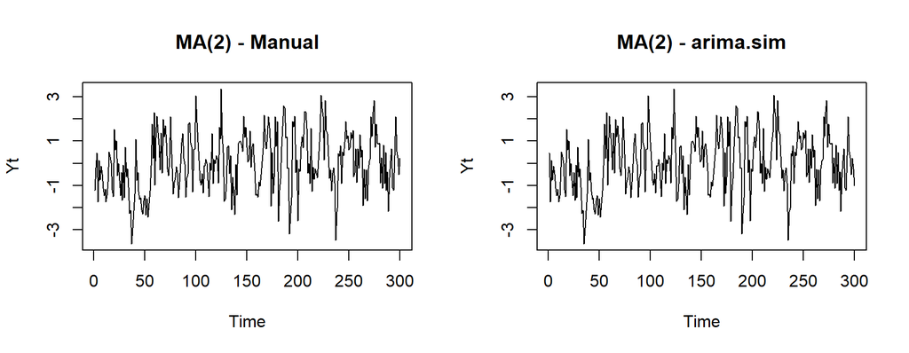

```r
par(mfrow = c(1, 2))
ts.plot(ma2, main = "MA(2) - Manual", ylab = "Yt")
ts.plot(ma2.sim, main = "MA(2) - arima.sim", ylab = "Yt")
```

```r
par(mfrow = c(1, 1))
```

## Plot ACF

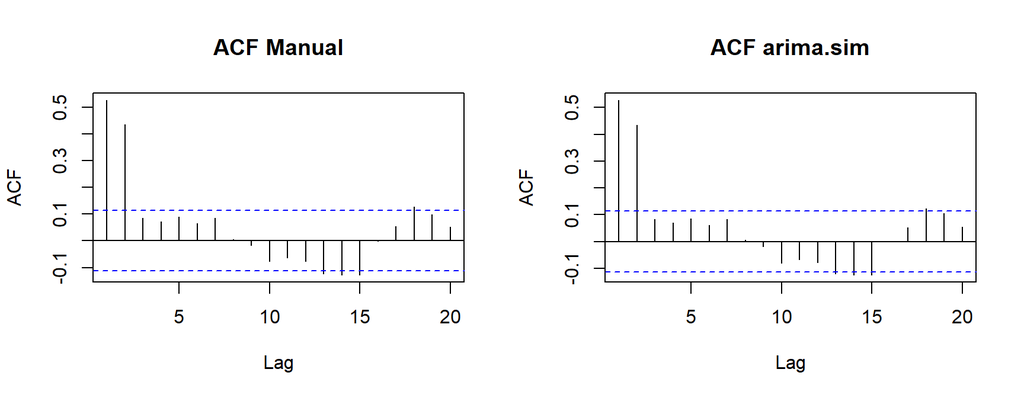

```r
par(mfrow = c(1, 2))
acf(ma2, lag.max = 20, main = "ACF Manual")
acf(ma2.sim, lag.max = 20, main = "ACF arima.sim")
```

```r
par(mfrow = c(1, 1))
```

## Plot PACF

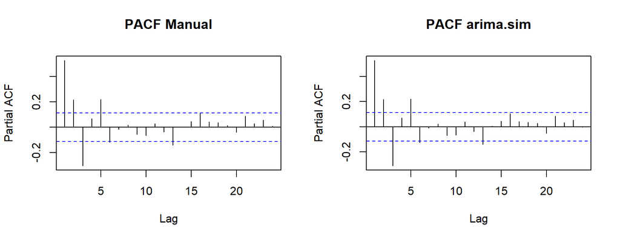

```r
par(mfrow = c(1, 2))
pacf(ma2, main = "PACF Manual")
pacf(ma2.sim, main = "PACF arima.sim")
```

```r
par(mfrow = c(1, 1))
```

## Plot EACF

```r
TSA::eacf(ma2)
```

```
## AR/MA
##   0 1 2 3 4 5 6 7 8 9 10 11 12 13
## 0 x x o o o o o o o o o  o  x  x
## 1 x x x o o o o o o o o  o  o  o
## 2 x x x x o o o o o o o  o  o  o
## 3 x x x x x o o o o o o  o  o  o
## 4 x x x x x o o o o o o  o  o  o
## 5 x x o x x o x o o o o  o  o  o
## 6 x x x o x o o x o o o  o  o  o
## 7 x o x o x o o x o o o  o  o  o
```

```r
TSA::eacf(ma2.sim)
```

```
## AR/MA
##   0 1 2 3 4 5 6 7 8 9 10 11 12 13
## 0 x x o o o o o o o o o  o  x  x
## 1 x x x o o o o o o o o  o  o  o
## 2 x x x x o o o o o o o  o  o  o
## 3 x x x x o o o o o o o  o  o  o
## 4 x x x x o o o o o o o  o  o  o
## 5 x x o x x o x o o o o  o  o  o
## 6 o x o o x o o x o o o  o  o  o
## 7 x o x o x o o x o o o  o  o  o
```

## Identifikasi Kestasioneran

Berdasarkan plot *time series*, data MA(2) berfluktuasi di sekitar nilai tengah (rataan nol) dengan ragam yang relatif konstan sepanjang waktu, sehingga data **stasioner dalam rataan maupun ragam**. Hal ini sesuai teori, karena proses MA berorde hingga selalu stasioner untuk sembarang nilai koefisien $\theta$. Pada plot ACF terlihat nilai autokorelasi signifikan (*cuts off*) setelah lag ke-2, sedangkan PACF cenderung *tails off* (menurun secara eksponensial/gelombang sinus). Pola segitiga nol pada EACF juga konsisten menunjukkan ordo AR(0) dan MA(2).

## Scatterplot Antar Lag

### $Y_t$ dengan $Y_{t-1}$

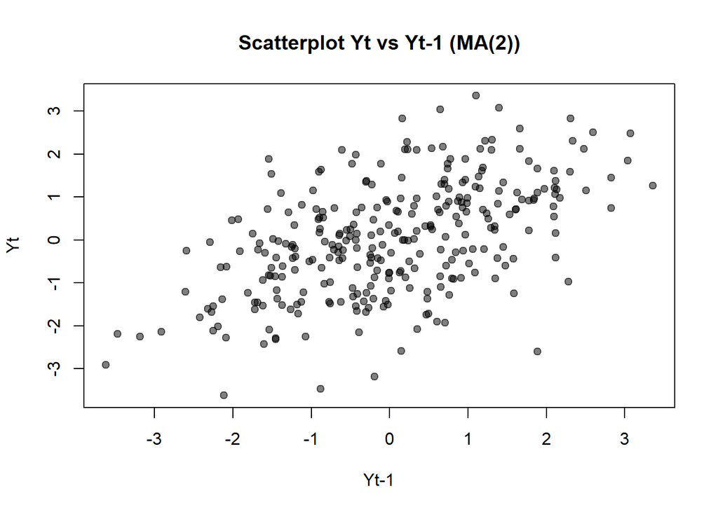

```r
yt_ma    <- ma2[-1]
yt1_ma   <- ma2[-n]
plot(y = yt_ma, x = yt1_ma, xlab = "Yt-1", ylab = "Yt",
     main = "Scatterplot Yt vs Yt-1 (MA(2))", pch = 19, col = rgb(0,0,0,0.5))
```

```r
cor(yt_ma, yt1_ma)
```

```
## [1] 0.5282201
```

### $Y_t$ dengan $Y_{t-2}$

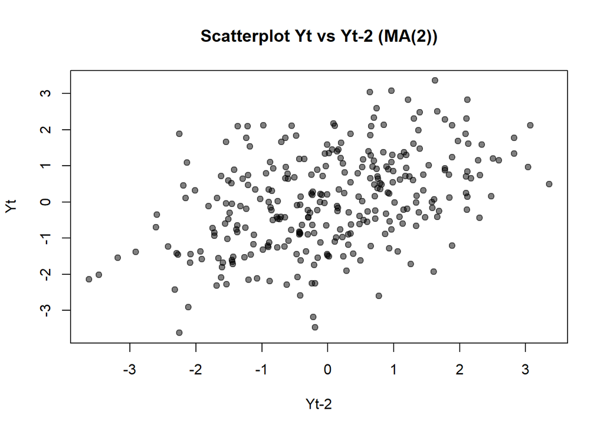

```r
yt_ma2  <- ma2[-c(1, 2)]
yt2_ma  <- ma2[-c(n - 1, n)]
plot(y = yt_ma2, x = yt2_ma, xlab = "Yt-2", ylab = "Yt",
     main = "Scatterplot Yt vs Yt-2 (MA(2))", pch = 19, col = rgb(0,0,0,0.5))
```

```r
cor(yt_ma2, yt2_ma)
```

```
## [1] 0.4356204
```

### $Y_t$ dengan $Y_{t-3}$

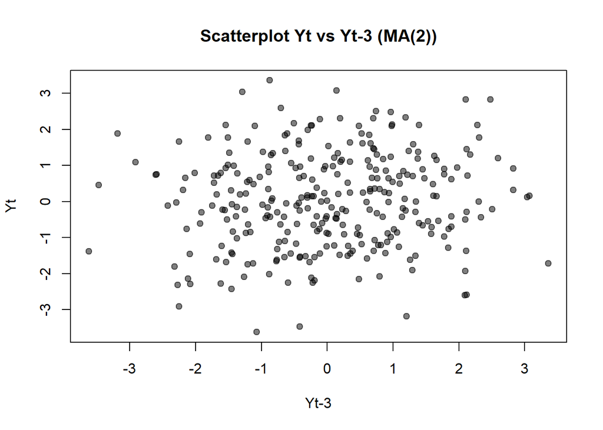

```r
yt_ma3  <- ma2[-c(1, 2, 3)]
yt3_ma  <- ma2[-c(n - 2, n - 1, n)]
plot(y = yt_ma3, x = yt3_ma, xlab = "Yt-3", ylab = "Yt",
     main = "Scatterplot Yt vs Yt-3 (MA(2))", pch = 19, col = rgb(0,0,0,0.5))
```

```r
cor(yt_ma3, yt3_ma)
```

```
## [1] 0.08544546
```

## Autokorelasi: Empiris vs Teoritis

Untuk MA(2), autokorelasi teoritis dirumuskan sebagai:
$$\rho_1=\frac{\theta_1+\theta_1\theta_2}{1+\theta_1^2+\theta_2^2},
\qquad
\rho_2=\frac{\theta_2}{1+\theta_1^2+\theta_2^2}, \qquad
\rho_k=0 \ \text{untuk } k \geq 3$$

```r
rho1_teori_ma <- (theta1 + theta1 * theta2) / (1 + theta1^2 + theta2^2)
rho2_teori_ma <- theta2 / (1 + theta1^2 + theta2^2)
rho3_teori_ma <- 0

data.frame(
  Lag = 1:3,
  Empiris  = c(cor(yt_ma, yt1_ma), cor(yt_ma2, yt2_ma), cor(yt_ma3, yt3_ma)),
  Teoritis = c(rho1_teori_ma, rho2_teori_ma, rho3_teori_ma)
)
```

```
##   Lag    Empiris  Teoritis
## 1   1 0.52822009 0.4210526
## 2   2 0.43562039 0.3947368
## 3   3 0.08544546 0.0000000
```

```r
# Verifikasi dengan fungsi ARMAacf()
ARMAacf(ma = c(theta1, theta2), lag.max = 5)
```

```
##         0         1         2         3         4         5
## 1.0000000 0.4210526 0.3947368 0.0000000 0.0000000 0.0000000
```

Terlihat bahwa nilai korelasi dari data bangkitan **mendekati** nilai korelasi teoritis, dan korelasi pada lag ke-3 mendekati nol – sesuai dengan sifat teoritis MA(2) yang terputus (*cuts off*) setelah lag ke-2.

# Proses AR(2)

Model yang dibangkitkan:
$$Y_t = \phi_1
Y_{t-1} + \phi_2 Y_{t-2} + e_t, \qquad \phi_1 = 0.5,\; \phi_2 =
0.2$$

## Pembangkitan Manual

```r
phi1 <- 0.5
phi2 <- 0.2

ar2 <- numeric(n)
ar2[1] <- wn[1]
ar2[2] <- wn[2] + phi1 * ar2[1]
for (i in 3:n) {
  ar2[i] <- phi1 * ar2[i - 1] + phi2 * ar2[i - 2] + wn[i]
}
ar2 <- ts(ar2)
head(ar2, 10)
```

```
## Time Series:
## Start = 1
## End = 10
## Frequency = 1
##  [1] -1.2070657 -0.3261036  0.6799762 -2.0709303 -0.4703452 -0.1433028
##  [7] -0.7404604 -0.9455226 -1.1853054 -1.6717950
```

## Pembangkitan dengan `arima.sim()`

```r
set.seed(1234)
ar2.sim <- arima.sim(list(order = c(2, 0, 0), ar = c(phi1, phi2)), n = n)
head(ar2.sim, 10)
```

```
## Time Series:
## Start = 1
## End = 10
## Frequency = 1
##  [1] -1.70663256 -0.40405718 -1.56701082 -0.87945515 -1.68907834  0.08186735
##  [7] -0.77247507 -1.07930411 -1.19540513 -2.44265685
```

## Plot Time Series

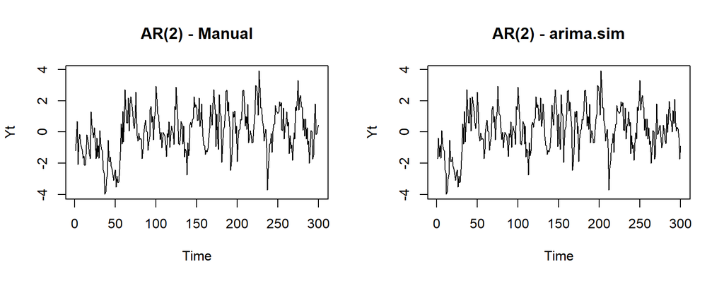

```r
par(mfrow = c(1, 2))
ts.plot(ar2, main = "AR(2) - Manual", ylab = "Yt")
ts.plot(ar2.sim, main = "AR(2) - arima.sim", ylab = "Yt")
```

```r
par(mfrow = c(1, 1))
```

## Plot ACF

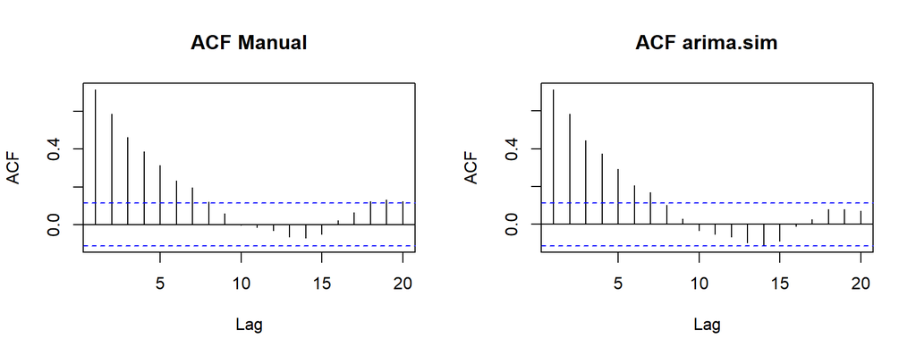

```r
par(mfrow = c(1, 2))
acf(ar2, lag.max = 20, main = "ACF Manual")
acf(ar2.sim, lag.max = 20, main = "ACF arima.sim")
```

```r
par(mfrow = c(1, 1))
```

## Plot PACF

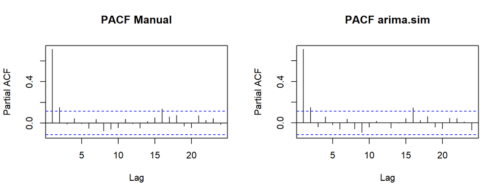

```r
par(mfrow = c(1, 2))
pacf(ar2, main = "PACF Manual")
pacf(ar2.sim, main = "PACF arima.sim")
```

```r
par(mfrow = c(1, 1))
```

## Plot EACF

```r
TSA::eacf(ar2)
```

```
## AR/MA
##   0 1 2 3 4 5 6 7 8 9 10 11 12 13
## 0 x x x x x x x x o o o  o  o  o
## 1 x o o o o o o o o o o  o  o  o
## 2 o o o o o o o o o o o  o  o  o
## 3 x x o o o o o o o o o  o  o  o
## 4 x x o o o o o o o o o  o  o  o
## 5 o x o x o o x o o o o  o  o  o
## 6 x x x x o o o o o o o  o  o  o
## 7 x x x o x x o o o o o  o  o  o
```

```r
TSA::eacf(ar2.sim)
```

```
## AR/MA
##   0 1 2 3 4 5 6 7 8 9 10 11 12 13
## 0 x x x x x x x o o o o  o  o  o
## 1 x o o o o o o o o o o  o  o  o
## 2 x o o o o o o o o o o  o  o  o
## 3 x x o o o o o o o o o  o  o  o
## 4 x x o o o o o o o o o  o  o  o
## 5 x x x o o o o o o o o  o  o  o
## 6 x x x o o o o o o o o  o  o  o
## 7 x x x o x x o o o o o  o  o  o
```

## Identifikasi Kestasioneran

Syarat kestasioneran AR(2) adalah $\phi_1+\phi_2<1$, $\phi_2-\phi_1<1$, dan $|\phi_2|<1$.

```r
c(phi1 + phi2 < 1, phi2 - phi1 < 1, abs(phi2) < 1)
```

```
## [1] TRUE TRUE TRUE
```

Ketiga syarat terpenuhi ($\phi_1=0.5$, $\phi_2=0.2$), sehingga proses AR(2) ini **stasioner**. Hal ini juga terlihat dari plot *time series* yang berfluktuasi di sekitar rataan yang konstan. Pada plot ACF terlihat pola *tails off* (menurun secara eksponensial), sedangkan PACF *cuts off* setelah lag ke-2 – sesuai dengan karakteristik teoritis AR(2).

## Scatterplot Antar Lag

### $Y_t$ dengan $Y_{t-1}$

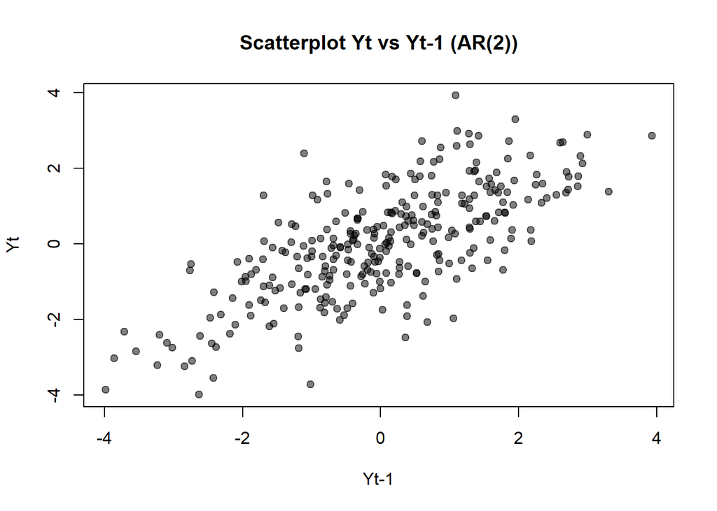

```r
yt_ar   <- ar2[-1]
yt1_ar  <- ar2[-n]
plot(y = yt_ar, x = yt1_ar, xlab = "Yt-1", ylab = "Yt",
     main = "Scatterplot Yt vs Yt-1 (AR(2))", pch = 19, col = rgb(0,0,0,0.5))
```

```r
cor(yt_ar, yt1_ar)
```

```
## [1] 0.7181941
```

### $Y_t$ dengan $Y_{t-2}$

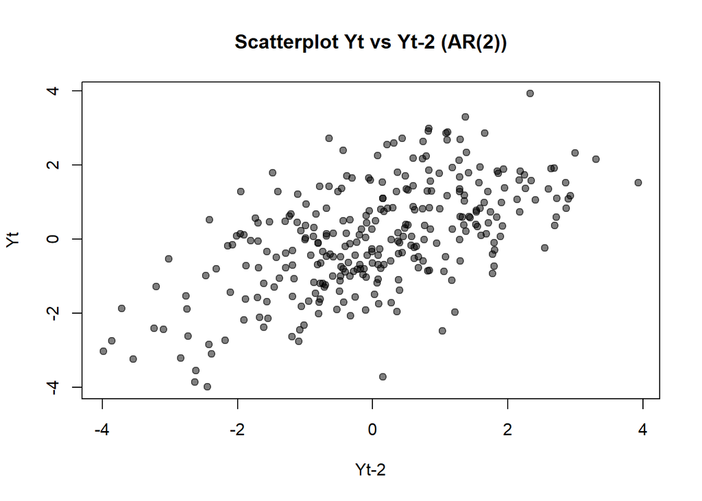

```r
yt_ar2  <- ar2[-c(1, 2)]
yt2_ar  <- ar2[-c(n - 1, n)]
plot(y = yt_ar2, x = yt2_ar, xlab = "Yt-2", ylab = "Yt",
     main = "Scatterplot Yt vs Yt-2 (AR(2))", pch = 19, col = rgb(0,0,0,0.5))
```

```r
cor(yt_ar2, yt2_ar)
```

```
## [1] 0.5889847
```

### $Y_t$ dengan $Y_{t-3}$

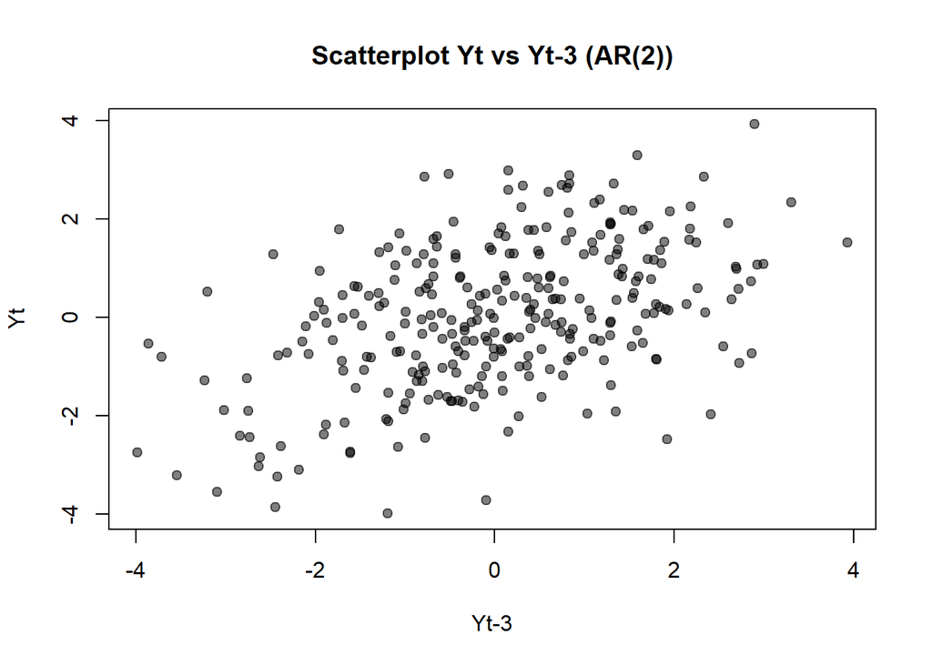

```r
yt_ar3  <- ar2[-c(1, 2, 3)]
yt3_ar  <- ar2[-c(n - 2, n - 1, n)]
plot(y = yt_ar3, x = yt3_ar, xlab = "Yt-3", ylab = "Yt",
     main = "Scatterplot Yt vs Yt-3 (AR(2))", pch = 19, col = rgb(0,0,0,0.5))
```

```r
cor(yt_ar3, yt3_ar)
```

```
## [1] 0.4630342
```

## Autokorelasi: Empiris vs Teoritis

Autokorelasi teoritis AR(2) diperoleh melalui persamaan Yule-Walker:
$$\rho_1=\frac{\phi_1}{1-\phi_2}, \qquad
\rho_2=\phi_1\rho_1+\phi_2, \qquad
\rho_3=\phi_1\rho_2+\phi_2\rho_1$$

```r
rho1_teori_ar <- phi1 / (1 - phi2)
rho2_teori_ar <- phi1 * rho1_teori_ar + phi2
rho3_teori_ar <- phi1 * rho2_teori_ar + phi2 * rho1_teori_ar

data.frame(
  Lag = 1:3,
  Empiris  = c(cor(yt_ar, yt1_ar), cor(yt_ar2, yt2_ar), cor(yt_ar3, yt3_ar)),
  Teoritis = c(rho1_teori_ar, rho2_teori_ar, rho3_teori_ar)
)
```

```
##   Lag   Empiris Teoritis
## 1   1 0.7181941  0.62500
## 2   2 0.5889847  0.51250
## 3   3 0.4630342  0.38125
```

```r
# Verifikasi dengan fungsi ARMAacf()
ARMAacf(ar = c(phi1, phi2), lag.max = 5)
```

```
##         0         1         2         3         4         5
## 1.0000000 0.6250000 0.5125000 0.3812500 0.2931250 0.2228125
```

Nilai autokorelasi dari data bangkitan mendekati nilai teoritisnya dan menurun secara perlahan (*tails off*) seiring bertambahnya lag, sesuai dengan karakteristik proses AR.

# Proses ARMA(2,2)

Model yang dibangkitkan:
$$Y_t = \phi_1
Y_{t-1} + \phi_2 Y_{t-2} + e_t + \theta_1 e_{t-1} + \theta_2
e_{t-2}$$
dengan $\theta_1 = 0.4$, $\theta_2 = 0.6$, $\phi_1 = 0.5$, $\phi_2 = 0.2$.

## Pembangkitan Manual

```r
arma22 <- numeric(n)
arma22[1] <- wn[1]
arma22[2] <- wn[2] + phi1 * arma22[1] + theta1 * wn[1]
for (i in 3:n) {
  arma22[i] <- phi1 * arma22[i - 1] + phi2 * arma22[i - 2] +
    wn[i] + theta1 * wn[i - 1] + theta2 * wn[i - 2]
}
arma22 <- ts(arma22)
head(arma22, 10)
```

```
## Time Series:
## Start = 1
## End = 10
## Frequency = 1
##  [1] -1.2070657 -0.8089299 -0.1747047 -1.9946020 -0.8907316 -1.5739991
##  [7] -1.0799887 -1.3276884 -2.0077907 -2.7132308
```

## Pembangkitan dengan `arima.sim()`

```r
set.seed(1234)
arma22.sim <- arima.sim(
  list(order = c(2, 0, 2), ar = c(phi1, phi2), ma = c(theta1, theta2)),
  n = n
)
head(arma22.sim, 10)
```

```
## Time Series:
## Start = 1
## End = 10
## Frequency = 1
##  [1] -2.751891 -1.748143 -2.980647 -1.121117 -1.752931 -1.338988 -2.090470
##  [8] -3.568293 -4.322252 -6.499328
```

## Plot Time Series

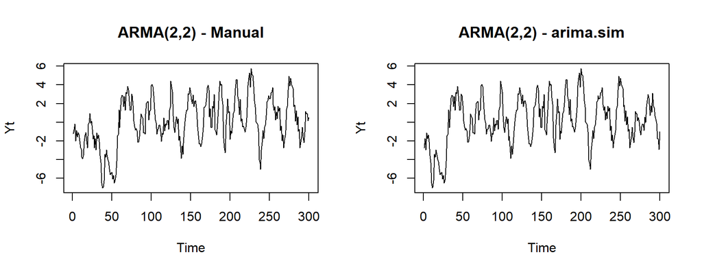

```r
par(mfrow = c(1, 2))
ts.plot(arma22, main = "ARMA(2,2) - Manual", ylab = "Yt")
ts.plot(arma22.sim, main = "ARMA(2,2) - arima.sim", ylab = "Yt")
```

```r
par(mfrow = c(1, 1))
```

## Plot ACF

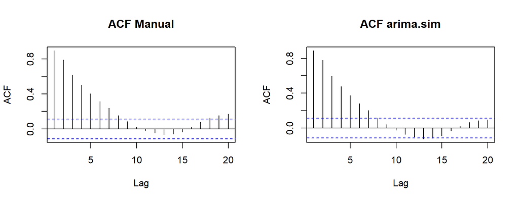

```r
par(mfrow = c(1, 2))
acf(arma22, lag.max = 20, main = "ACF Manual")
acf(arma22.sim, lag.max = 20, main = "ACF arima.sim")
```

```r
par(mfrow = c(1, 1))
```

## Plot PACF

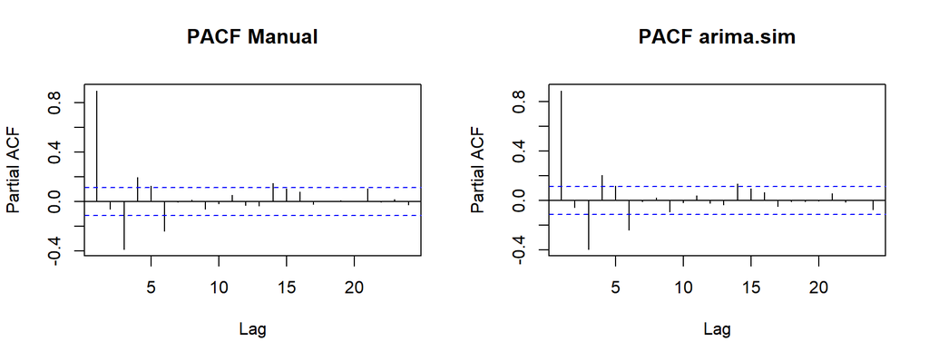

```r
par(mfrow = c(1, 2))
pacf(arma22, main = "PACF Manual")
pacf(arma22.sim, main = "PACF arima.sim")
```

```r
par(mfrow = c(1, 1))
```

## Plot EACF

```r
TSA::eacf(arma22)
```

```
## AR/MA
##   0 1 2 3 4 5 6 7 8 9 10 11 12 13
## 0 x x x x x x x x o o o  o  o  o
## 1 o x o o o o x o o o o  o  o  o
## 2 x x o o o o x o o o o  o  o  o
## 3 x x o x o o x o o o o  o  o  o
## 4 x x x x o o x o o o o  o  o  o
## 5 x x x x x x x o o o o  o  o  o
## 6 o o x o x x o o o o o  o  o  o
## 7 o o x o x x o x o o o  o  o  o
```

```r
TSA::eacf(arma22.sim)
```

```
## AR/MA
##   0 1 2 3 4 5 6 7 8 9 10 11 12 13
## 0 x x x x x x x o o o o  o  x  o
## 1 o x o o o o x o o o o  o  o  o
## 2 x x o o o o o o o o o  o  o  o
## 3 x x x x o o o o o o o  o  o  o
## 4 x x x x o o o o o o o  o  o  o
## 5 x x x x x x x o o o o  o  o  o
## 6 o o x o x x o o o o o  o  o  o
## 7 x o x x x x o x o o o  o  o  o
```

## Identifikasi Kestasioneran

Bagian AR pada model ARMA(2,2) memiliki koefisien yang sama dengan proses AR(2) sebelumnya ($\phi_1=0.5$, $\phi_2=0.2$), yang telah memenuhi syarat kestasioneran ($\phi_1+\phi_2<1$, $\phi_2-\phi_1<1$, $|\phi_2|<1$). Oleh karena itu proses ARMA(2,2) ini **stasioner**. Pada plot *time series*, data berfluktuasi di sekitar rataan yang konstan. Baik ACF maupun PACF cenderung *tails off* (menurun secara bertahap/membentuk gelombang), sesuai dengan karakteristik campuran AR dan MA pada proses ARMA.

## Scatterplot Antar Lag

### $Y_t$ dengan $Y_{t-1}$

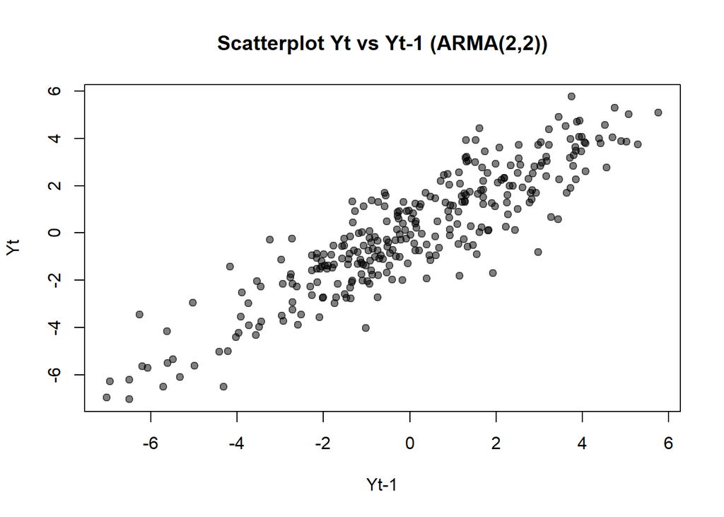

```r
yt_arma   <- arma22[-1]
yt1_arma  <- arma22[-n]
plot(y = yt_arma, x = yt1_arma, xlab = "Yt-1", ylab = "Yt",
     main = "Scatterplot Yt vs Yt-1 (ARMA(2,2))", pch = 19, col = rgb(0,0,0,0.5))
```

```r
cor(yt_arma, yt1_arma)
```

```
## [1] 0.8955216
```

### $Y_t$ dengan $Y_{t-2}$

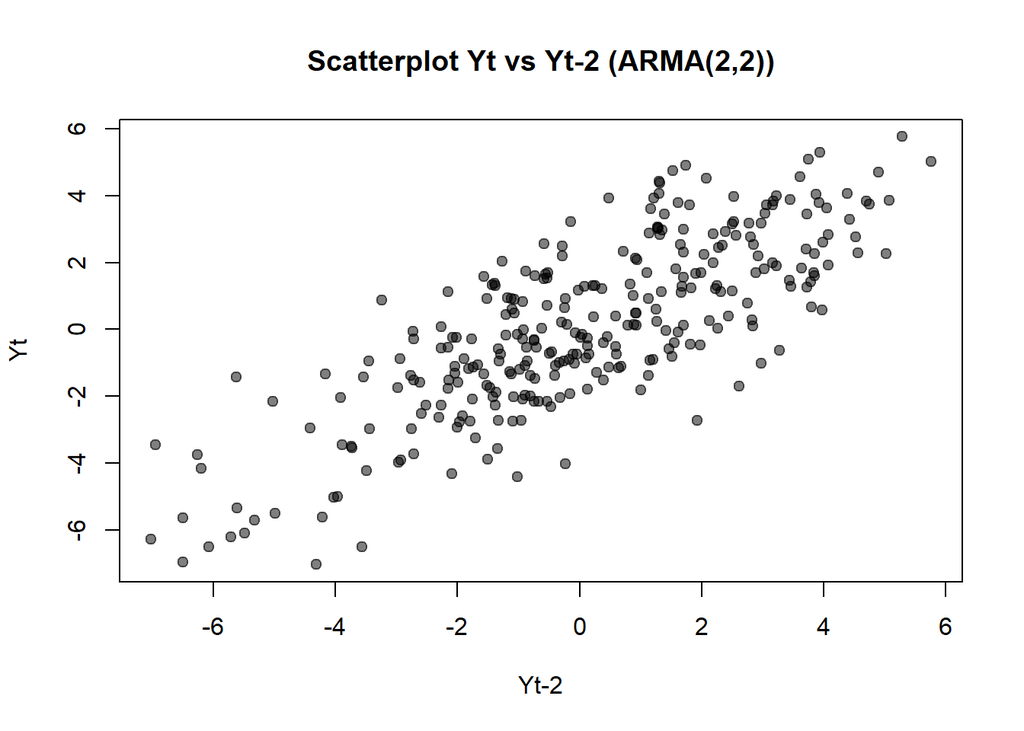

```r
yt_arma2  <- arma22[-c(1, 2)]
yt2_arma  <- arma22[-c(n - 1, n)]
plot(y = yt_arma2, x = yt2_arma, xlab = "Yt-2", ylab = "Yt",
     main = "Scatterplot Yt vs Yt-2 (ARMA(2,2))", pch = 19, col = rgb(0,0,0,0.5))
```

```r
cor(yt_arma2, yt2_arma)
```

```
## [1] 0.7899614
```

### $Y_t$ dengan $Y_{t-3}$

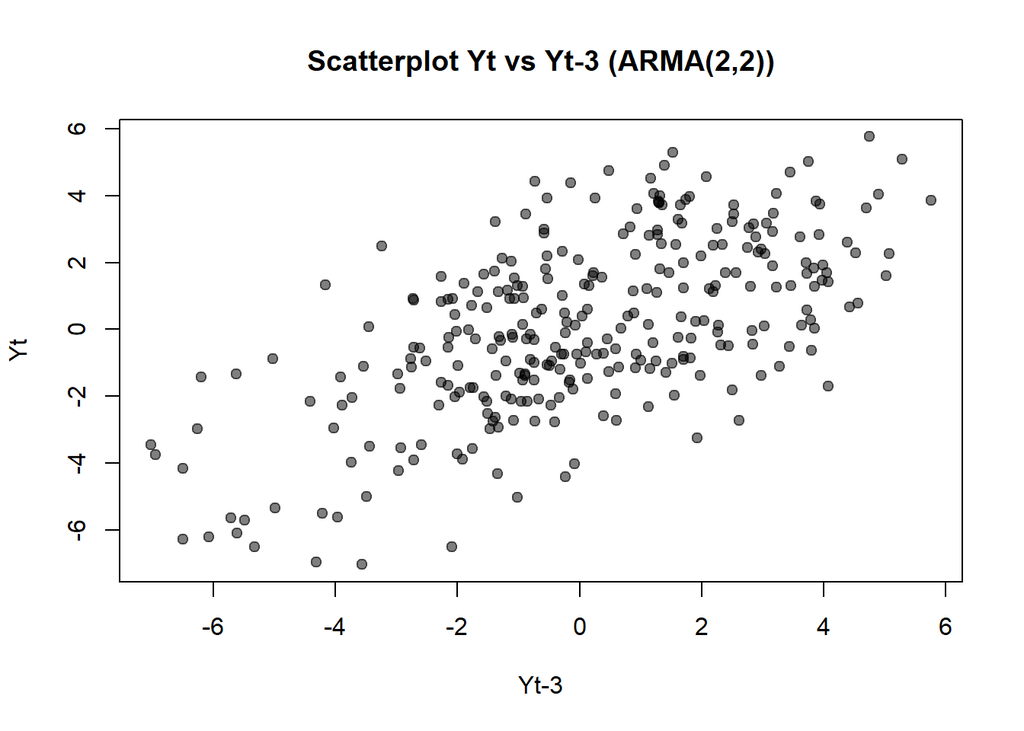

```r
yt_arma3  <- arma22[-c(1, 2, 3)]
yt3_arma  <- arma22[-c(n - 2, n - 1, n)]
plot(y = yt_arma3, x = yt3_arma, xlab = "Yt-3", ylab = "Yt",
     main = "Scatterplot Yt vs Yt-3 (ARMA(2,2))", pch = 19, col = rgb(0,0,0,0.5))
```

```r
cor(yt_arma3, yt3_arma)
```

```
## [1] 0.6195458
```

## Autokorelasi: Empiris vs Teoritis

Untuk proses ARMA(p,q), autokorelasi teoritis tidak memiliki bentuk tertutup yang sederhana seperti AR atau MA murni, sehingga dihitung melalui fungsi `ARMAacf()` di R yang menyelesaikan persamaan rekursif teoritisnya.

```r
acf_teori_arma <- ARMAacf(ar = c(phi1, phi2), ma = c(theta1, theta2), lag.max = 3)
acf_teori_arma
```

```
##         0         1         2         3
## 1.0000000 0.8591993 0.7491908 0.5464353
```

```r
data.frame(
  Lag = 1:3,
  Empiris  = c(cor(yt_arma, yt1_arma), cor(yt_arma2, yt2_arma), cor(yt_arma3, yt3_arma)),
  Teoritis = as.numeric(acf_teori_arma[2:4])
)
```

```
##   Lag   Empiris  Teoritis
## 1   1 0.8955216 0.8591993
## 2   2 0.7899614 0.7491908
## 3   3 0.6195458 0.5464353
```

# Ringkasan

| Proses | Koefisien | Kestasioneran | Ciri ACF | Ciri PACF |
| --- | --- | --- | --- | --- |
| MA(2) | $\theta_1=0.4,\ \theta_2=0.6$ | Stasioner | *cuts off* lag 2 | *tails off* |
| AR(2) | $\phi_1=0.5,\ \phi_2=0.2$ | Stasioner | *tails off* | *cuts off* lag 2 |
| ARMA(2,2) | $\phi_1=0.5,\ \phi_2=0.2,\ \theta_1=0.4,\ \theta_2=0.6$ | Stasioner | *tails off* | *tails off* |

Ketiga proses yang dibangkitkan (masing-masing 300 data) bersifat **stasioner**, dan pola ACF/PACF/EACF yang diperoleh dari data bangkitan konsisten dengan teori identifikasi model Box-Jenkins.